# Chap6

```r
library (dplyr)
library (tidyverse)
```

```r
library (ggplot2)
library (tidyr)
library (corrplot)
library (lme4)
```

Data sets were prepared in meet_and_repeat.R file

**Chapter 8 in MABS: analysis of longitudinal data : Graphical displays and summary measure approach using** RATS** data

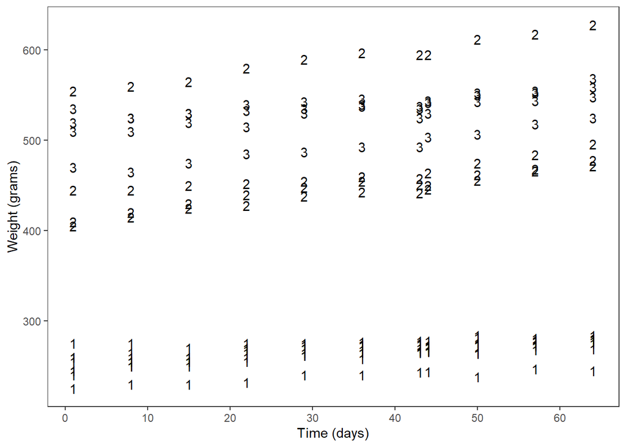

```r
#read data
RATSL<- read.csv ("rats.csv", row.names = 1)
# raw graphic

fig1 <- ggplot(RATSL, aes(x = Time, y = Weight, group = ID))+ geom_text(aes(label = Group))+ scale_x_continuous(name = "Time (days)", breaks = seq(0, 60, 10)) + scale_y_continuous(name = "Weight (grams)") + theme_bw() + theme(panel.grid.major = element_blank(), panel.grid.minor = element_blank())
fig1
```

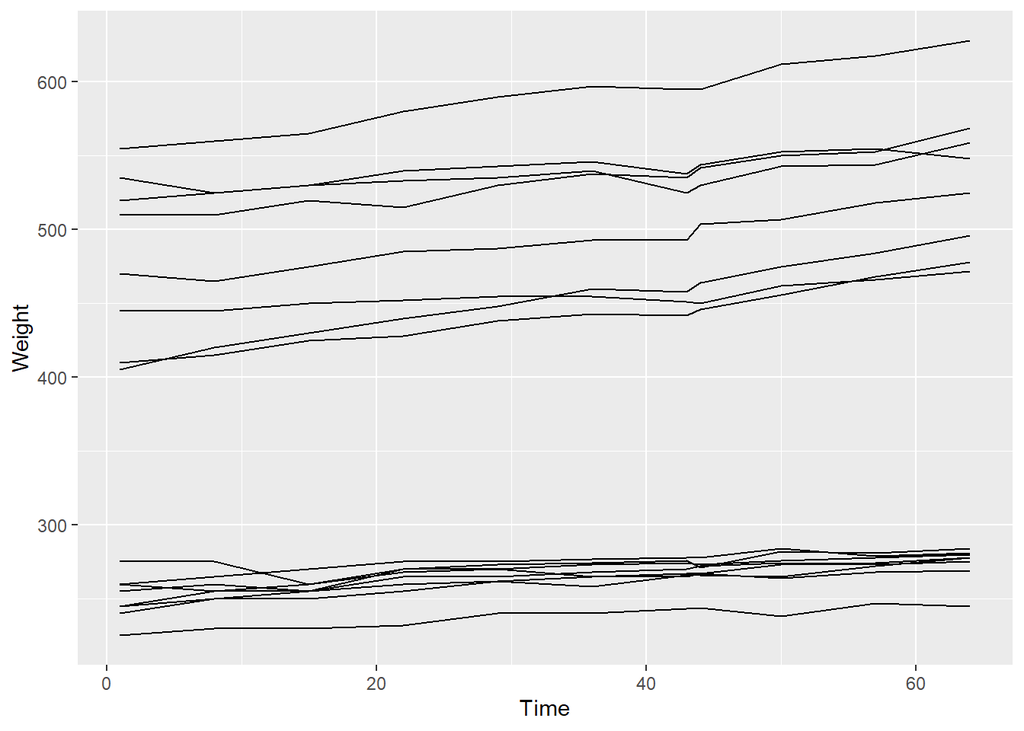

```r
fig2 <- ggplot(RATSL, aes(x = Time, y = Weight, group = ID)) +
  geom_line()
fig2
```

*** Data description Data was extracted from a nutrition study conducted in three groups of rats (Crowder and Hand, 1990).

*ID*: number of rats in study

*Group*: three groups in study (1,2,3)

Variables (*weight*): body weight (grams)

**Interpret** we want to see the diffecences between the variable *weight* of rats changing during the time in 3 groups.

It can be seen from the fig1 above: group 1 seperate compared group2 and 3. Group 2 and 3 are duplicated, somehow we can guess there is no difference between group 2 and 3.

**Scatterplot matrix of repeated measures in rat growth data with raw data to see independent of variables

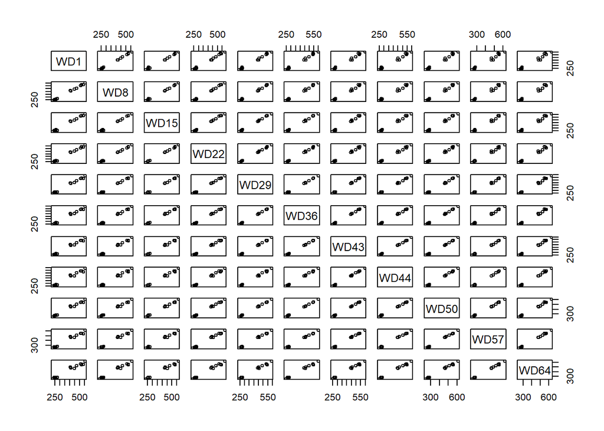

```r
RATS <- read.table("https://raw.githubusercontent.com/KimmoVehkalahti/MABS/master/Examples/data/rats.txt", header = TRUE, sep = '\t')
pairs(RATS[, 3:13], cex = 0.7)
```

a scatterplot matrix of the repeated measures of weight does demonstrate that the repeated measures are certainly not independent of one another